# mid_term_e106

Gurdeep

25/10/2020

```r
rm(list = ls())

setwd("/cloud/project/HW//mid_term_real") # change to local directory before running

library(knitr)
library(onewaytests)
library(olsrr)
library(lmtest)
library(MASS)
library(ALSM)
```

1a-) Create development sample and hold out sample. Development sample is a random sample of 70% of the data and hold out sample is the remainder 30% of the data. Use “set.seed(1023)” to select the samples. (5 pts)

```r
# read in the data set
mtq1 <- read.csv('Midterm Q1 Data Set.csv')
head(mtq1)
```

```
##      y  x
## 1 2300 35
## 2 2500 60
## 3 4000 30
## 4  500 20
## 5 4400 50
## 6 1900 18
```

```r
colnames(mtq1)
```

```
## [1] "y" "x"
```

```r
dim(mtq1)
```

```
## [1] 496   2
```

```r
# number of values in development and hold out set
n_dev <- round(0.7*nrow(mtq1))
n_hold <- nrow(mtq1) - n_dev

set.seed(1023)

# index of the samples
dev_ind <- sample(1:nrow(mtq1), n_dev)

# create development and holdout samples
mtq1_dev <- mtq1[dev_ind,]
mtq1_hold <- mtq1[-dev_ind,]
```

The holdout and development samples are created as above.

b-) Build a regression model to predict Y as a function of X on the development sample. Write down the regression model, Is the regression model significant? (5 points)

```r
# fit the regression
reg1b <- lm(y~x, data = mtq1_dev)
summary(reg1b)
```

```
##
## Call:
## lm(formula = y ~ x, data = mtq1_dev)
##
## Residuals:
##     Min      1Q  Median      3Q     Max
## -2803.6  -933.3  -233.3   572.1  6966.7
##
## Coefficients:
##             Estimate Std. Error t value Pr(>|t|)
## (Intercept) 1257.562    146.831   8.565 3.65e-16 ***
## x             47.030      5.469   8.599 2.86e-16 ***
## ---
## Signif. codes:  0 '***' 0.001 '**' 0.01 '*' 0.05 '.' 0.1 ' ' 1
##
## Residual standard error: 1398 on 345 degrees of freedom
## Multiple R-squared:  0.1765, Adjusted R-squared:  0.1741
## F-statistic: 73.94 on 1 and 345 DF,  p-value: 2.858e-16
```

```r
ei_1b <- reg1b$residuals
```

The regression model is written as y = 1257.562 + 47.030 * x

From the summary above we see that the regression has an F-statistic = 73.94 with p-value = 2.858e-16.

The p-values of the individual coefficients are also below the rejection thresholds (assuming 95% confidence levels).

Hence, we conclude that the regression is significant.

c-) Obtain, the residuals and plot them against the fitted values. Also prepare a normal probability plot. What do your plots show? Conduct the Breusch-Pagan Test to determine whether or not the error variances are constant. (10 points)

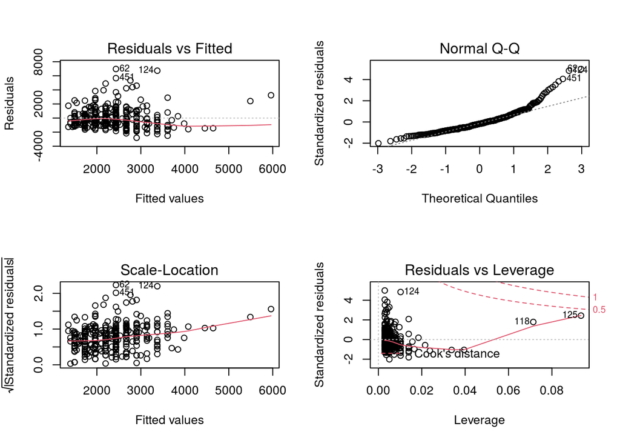

```r
# plot residuals and other standard plots
old.par <- par(mfrow = c(2,2))
plot(reg1b)
```

```r
old.par
```

```
## $mfrow
## [1] 1 1
```

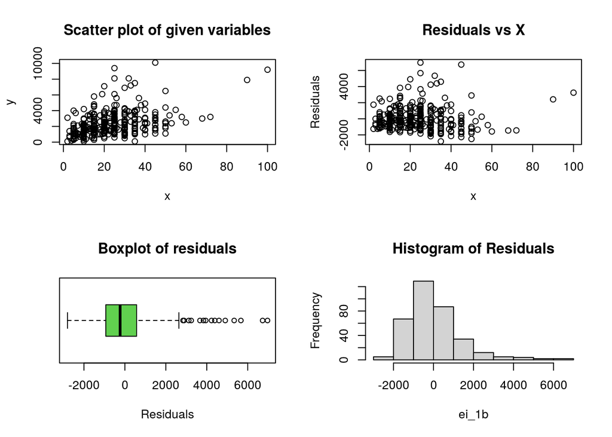

```r
newer.par = par(mfrow = c(2,2))
plot(mtq1_dev$x, mtq1_dev$y, xlab = 'x', ylab = 'y', main = 'Scatter plot of given variables')
plot(mtq1_dev$x,ei_1b, xlab = 'x', ylab = 'Residuals', main = 'Residuals vs X')
boxplot(ei_1b, horizontal = TRUE, staplewax = 0.5, col = 3, xlab = 'Residuals', main = 'Boxplot of residuals')
hist(ei_1b, main = 'Histogram of Residuals')
```

```r
newer.par
```

```
## $mfrow
## [1] 2 2
```

```r
# BP Test
bptest(reg1b)
```

```
##
##  studentized Breusch-Pagan test
##
## data:  reg1b
## BP = 9.947, df = 1, p-value = 0.001611
```

```r
# Ho : Errors are normally distributed; no heteroskedasticicty
# Ha : Errors are not normally distributed

# Decision Rule: p-value > 0.05 ==> Accept Ho
```

From the Regression plots we see that

Residuals vs fitted values plot 1. higher dispersion for positive residuals; not random 2. There are outliers present

Q-Q plot 1. The line is not 45 degrees 2. values start diverging after +1.5 SD

Scatterplot of x & y 1. Shows a curvilinear relationship

Boxplot 1. high number of outliers for higher values of x

This shows us that the following regression assumptions are not satisfied

1. Linearity of the regression function
2. Error terms have constant variance
3. Error terms are normally distributed
4. Error terms are independent
5. Model fits all but 1 or few outliers

BP Test

The above conclusions are also supported by the results of the B-P test. For the BP test we have the decision rule as

Ho : Errors are normally distributed; no heteroskedasticicty Ha : Errors are not normally distributed

Decision Rule: p-value > 0.05 ==> Accept Ho

The p-value of the BP test = 0.00161. This is less than 0.05 threshold and we reject Ho and conclude that heteroskedasticity is present in the dataset.

d-) Calculate the simultaneous 90% confidence interval for $\beta_{0}$,and $\beta_{1}$ and calculate the simultaneous 90% confidence intervals for the predicted new X values for 85 and 90. (10 pts)

```r
# simultaneous 90% confidence interval for beta0 and beta1
confint(reg1b, level = 1-0.1/2) # family CI
```

```
##                2.5 %     97.5 %
## (Intercept) 968.7645 1546.35876
## x            36.2730   57.78799
```

```r
# simultaneous prediction intervals for new observations
# since new values are asked we use Bonferroni and Scheffe tests

xh <- c(85,90)
g <- length(xh)
alpha <- 0.05

ci.new <- predict.lm(reg1b, data.frame(x = c(xh)), se.fit = TRUE, level = 1-alpha)
ci.new
```

```
## $fit
##        1        2
## 5255.153 5490.306
##
## $se.fit
##        1        2
## 346.9262 373.6720
##
## $df
## [1] 345
##
## $residual.scale
## [1] 1398.417
```

```r
m <- rbind(rep(qt(1-alpha/(2*g), reg1b$df.residual),g), rep(sqrt(g*qf(1-alpha, g, reg1b$df.residual)),g) )
# repeat t-value g times; repeat f-value g times
m
```

```
##          [,1]     [,2]
## [1,] 2.251228 2.251228
## [2,] 2.458413 2.458413
```

```r
spred <- sqrt(ci.new$residual.scale^2 + (ci.new$se.fit)^2)
spred
```

```
##        1        2
## 1440.808 1447.481
```

```r
# put all values in a transpose matrix
pred.new <- t(rbind(
  'Yh' = xh,
  'spred' = spred,
  'fit' = ci.new$fit,
  'lower.B' = ci.new$fit - m[1,] * spred,
  'upper.B' = ci.new$fit + m[1,] * spred,
  'lower.s' = ci.new$fit - m[2,] * spred,
  'upper.s' = ci.new$fit + m[2,] * spred))

# display required value
pred.new
```

```
##   Yh    spred      fit  lower.B  upper.B  lower.s  upper.s
## 1 85 1440.808 5255.153 2011.565 8498.741 1713.052 8797.255
## 2 90 1447.481 5490.306 2231.696 8748.916 1931.800 9048.812
```

Confidence intervals using Bonferoni and Schefe intervals are calculated above.

e-) Use the Box-Cox procedure to find an appropriate power transformation and perform the transformation. Obtain, the residuals and plot them against the fitted values. Also prepare a normal probability plot. What do your plots show? (10 pts)

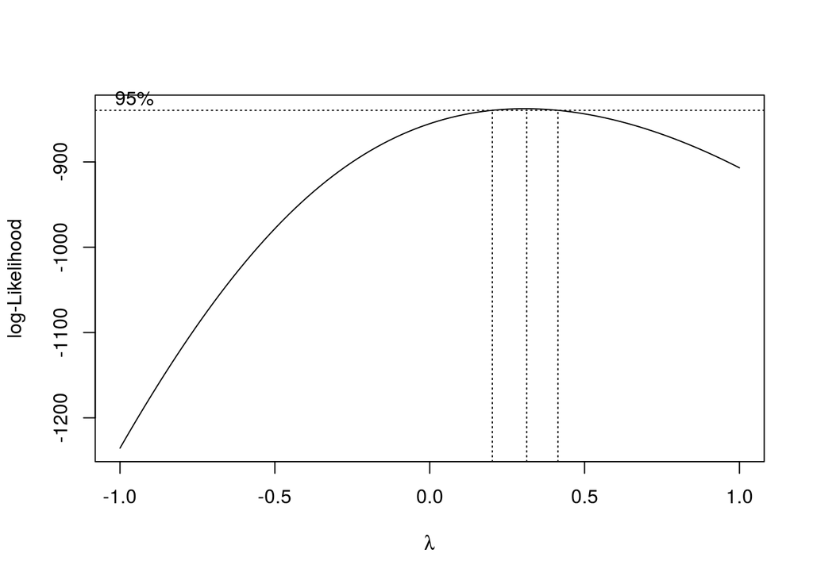

```r
# use the boxcox transformation
boxcox(reg1b, lambda = seq(-1.0, 1.0,0.1))
```

```r
# use the boxcox transformation
# fit the regression
reg1e <- lm(sqrt(y)~x, data = mtq1_dev)
summary(reg1e)
```

```
##
## Call:
## lm(formula = sqrt(y) ~ x, data = mtq1_dev)
##
## Residuals:
##     Min      1Q  Median      3Q     Max
## -41.621  -8.579  -0.966   7.689  49.965
##
## Coefficients:
##             Estimate Std. Error t value Pr(>|t|)
## (Intercept) 35.40728    1.40265  25.243   <2e-16 ***
## x            0.46325    0.05225   8.866   <2e-16 ***
## ---
## Signif. codes:  0 '***' 0.001 '**' 0.01 '*' 0.05 '.' 0.1 ' ' 1
##
## Residual standard error: 13.36 on 345 degrees of freedom
## Multiple R-squared:  0.1856, Adjusted R-squared:  0.1832
## F-statistic: 78.61 on 1 and 345 DF,  p-value: < 2.2e-16
```

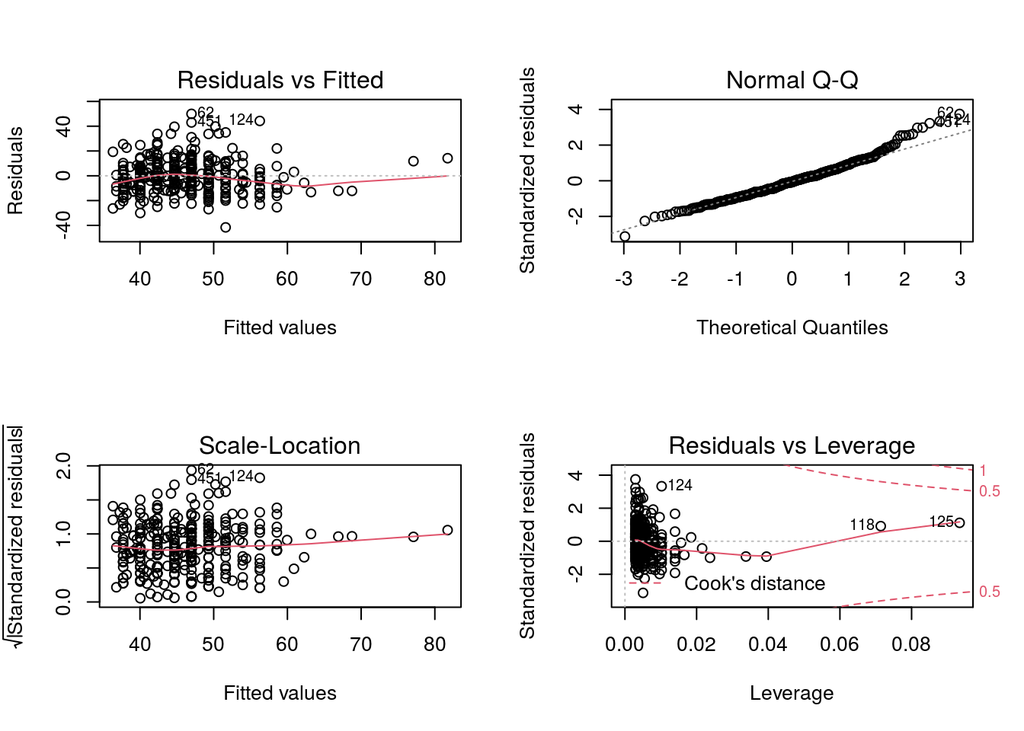

```r
ei_1e <- reg1e$residuals

# plot residuals and other standard plots
old.par <- par(mfrow = c(2,2))
plot(reg1e)
```

```r
old.par
```

```
## $mfrow
## [1] 1 1
```

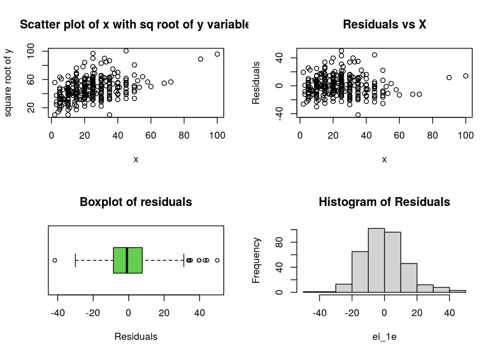

```r
newer.par = par(mfrow = c(2,2))
plot(mtq1_dev$x, sqrt(mtq1_dev$y), xlab = 'x', ylab = 'square root of y', main = 'Scatter plot of x with sq root of y variable')
plot(mtq1_dev$x,ei_1e, xlab = 'x', ylab = 'Residuals', main = 'Residuals vs X')
boxplot(ei_1e, horizontal = TRUE, staplewax = 0.5, col = 3, xlab = 'Residuals', main = 'Boxplot of residuals')
hist(ei_1e, main = 'Histogram of Residuals')
```

```r
newer.par
```

```
## $mfrow
## [1] 2 2
```

```r
# BP Test
bptest(reg1e)
```

```
##
##  studentized Breusch-Pagan test
##
## data:  reg1e
## BP = 1.4082, df = 1, p-value = 0.2353
```

```r
# Ho : Errors are normally distributed; no heteroskedasticicty
# Ha : Errors are not normally distributed

# Decision Rule: p-value > 0.05 ==> Accept Ho
```

From the Regression plots we see that

Residuals vs fitted values plot 1. Mostly random distribution 2. There are outliers present but lesser and closer to the bulk of the distribution

Q-Q plot 1. The line is at 45 degrees 2. Residuals start diverging only close to 2 SD

Scatterplot of x & y 1. Shows a linear relationship

Residuals vs X plot 1. Shows random distribution

Boxplot 1. Symmetrical with few outliers for higher values of x

Histogram of residuals 1. close to normal distribution

This shows us that the following regression assumptions are now satisfied

1. Linearity of the regression function
2. Error terms have constant variance
3. Error terms are normally distributed
4. Error terms are independent
5. Model fits all but 1 or few outliers

BP Test

The above conclusions are also supported by the results of the B-P test. For the BP test we have the decision rule as

Ho : Errors are normally distributed; no heteroskedasticicty Ha : Errors are not normally distributed

Decision Rule: p-value > 0.05 ==> Accept Ho

f-) Calculate R Square on the hold out sample (hint: calculate SSE, SSR and SST on the hold out sample). Is the model performance robust? (10 pts)

```r
head(mtq1_hold)
```

```
##       y  x
## 3  4000 30
## 4   500 20
## 7  3600 25
## 8  2200 21
## 14 4400 15
## 21 1300 25
```

```r
yhat_hold <- predict(reg1e, data.frame(x = mtq1_hold$x))^2
ybar_hold <- mean(mtq1_hold$y)

ssr_1f <- sum((yhat_hold - ybar_hold)^2)
ssr_1f
```

```
## [1] 37913946
```

```r
sst_1f <- sum((mtq1_hold$y - ybar_hold)^2)
sst_1f
```

```
## [1] 271706711
```

```r
r2 <- ssr_1f/sst_1f
r2
```

```
## [1] 0.13954
```

The model has R2 of 0.13954 on the holdout set while the development set had an R2 of 0.1856. While the R2 value for both is low, the lower value of R2 for holdout set compared to development set is to be expected since the model is predicting for a dataset that it has not seen before.